# Hawaii SNAP Analysis: Interactive Homework

Using Census Data & Machine Learning to Understand Food Security

Author

DS 400: Bayesian Statistics & Data Science

Published

October 23, 2025

## 🌺 Introduction: Food Security in Hawaiʻi

Food security is a critical health and equity issue. The Supplemental Nutrition Assistance Program (SNAP) helps vulnerable households afford nutritious food. But which communities have the highest rates of food assistance participation? And what factors are most strongly associated with SNAP participation?

In this assignment, you’ll:

1. **Access Census data** using `tidycensus`
2. **Explore patterns** of SNAP participation across Hawaiʻi census tracts
3. **Build a predictive model** using Random Forests
4. **Interpret results** using SHAP (Explainable AI) techniques

**Homework Requirements**

- ✅ Complete all **CHALLENGE** sections
- ✅ Provide code AND written explanations
- ✅ Show your thinking - comment your code!
- ✅ Answer reflection questions at the end
- ⭐ Bonus: Try the extension questions for extra credit

**Due Date**: [Before Class, 2:30 PM pm 10/23/25]

## 📦 Load Libraries

```r
library(ggplot2)
library(tidycensus)
library(dplyr)
library(tidyr)
library(stringr)
library(mapgl)
library(viridis)
library(randomForest)
library(treeshap)
library(mapview)
library(sf)
```

## 📊 Part 1: Collect Census Data

### Set Up Your Census Variables

The code below defines the Census Bureau variables we’ll use. These come from the American Community Survey (ACS) 5-Year Estimates.

```r
# Define ACS variables for Hawaii
# (Population, poverty, insurance, employment, housing, broadband, education, income, SNAP)

hi_vars <- c(
  # Person-level
  poverty_n            = "B17001_002",
  uninsured_u65_n      = "B27010_017",
  unemployed_n         = "B23025_005",
  pop_total            = "B01003_001",

  # Households + housing
  households_total     = "B11001_001",
  broadband_hh_n       = "B28002_004",
  renter_hh_n          = "B25003_003",
  novehicle_hh_n       = "B25044_003",
  snap_hh_n            = "B22001_002",     # <-- SNAP households

  # Education
  edu_25plus_total     = "B15003_001",
  bachelors_n          = "B15003_022",

  # Labor force + workers
  labor_force_total    = "B23025_003",
  workers_total        = "B08301_001",

  # Income level
  median_income        = "B19013_001"
)
```

**Understanding Census Variables**

Each variable code (like “B17001_002”) refers to a specific data table and line number from the Census Bureau. The naming convention is: - **B** = Detailed table - **17001** = Table ID (in this case, poverty data) - **002** = Specific line number (usually the numerator for a percentage calculation)

For more info, check the [Census Bureau Data API documentation](https://api.census.gov/data/2023/acs/acs5/variables.html)

### Pull Data from the Census API

```r
# Pull core variables (long format, then pivot to wide)
hi_acs_long <- get_acs(
  geography = "tract",
  state = "HI",
  year = 2023,
  geometry = TRUE,
  variables = hi_vars
)|>
  dplyr::filter(GEOID != "15003981200")

# Convert to wide format (one row per census tract)
hi_acs <- hi_acs_long %>%
  select(GEOID, variable, estimate) %>%
  pivot_wider(names_from = variable, values_from = estimate)
```

**Note**

Census data loaded successfully! (Output suppressed to keep document clean)

### Calculate Commute Times (≥30 minutes)

```r
# Get commute time data using table lookup
commute_tbl <- get_acs(
  geography = "tract",
  state = "HI",
  year = 2023,
  table = "B08303",
  geometry = FALSE
)|>
  dplyr::filter(GEOID != "15003981200")

# Extract commute ≥30 min variable
commute_30plus <- commute_tbl %>%
  filter(variable == "B08303_004") %>%
  group_by(GEOID) %>%
  summarize(commute_30plus_n = sum(estimate, na.rm = TRUE), .groups = "drop")
```

## 🧮 Part 2: Calculate Percentages & Clean Data

The code below joins all the data and calculates percentages. Study how we normalize each variable!

```r
# Join commute data and calculate all percentages
hi_acs <- hi_acs %>%
  left_join(commute_30plus, by = "GEOID") %>%
  mutate(
    # Person-based percentages
    poverty_rate_pct        = 100 * poverty_n       / pmax(pop_total, 1),
    uninsured_u65_pct       = 100 * uninsured_u65_n / pmax(pop_total, 1),

    # Labor-force based
    unemployment_rate_pct   = 100 * unemployed_n    / pmax(labor_force_total, 1),

    # Household-based percentages
    broadband_pct           = 100 * broadband_hh_n  / pmax(households_total, 1),
    renter_pct              = 100 * renter_hh_n     / pmax(households_total, 1),
    no_vehicle_pct          = 100 * novehicle_hh_n  / pmax(households_total, 1),
    snap_pct                = 100 * snap_hh_n       / pmax(households_total, 1),

    # Education (25+)
    bachelors_or_higher_pct = 100 * bachelors_n     / pmax(edu_25plus_total, 1),

    # Commute-based
    commute_30plus_pct      = 100 * commute_30plus_n / pmax(workers_total, 1)
  )
```

**Why `pmax(denominator, 1)`?**

This prevents division by zero errors. If a census tract has 0 people, we use 1 as the denominator instead. The `pmax()` function takes the parallel maximum - comparing each value to 1 element-wise.

## 🗺️ CHALLENGE 1: Map SNAP Participation

**Your Task**

Create a map showing SNAP participation rates by census tract across Hawaiʻi. You should:

1. **Use `ggplot2`** with `geom_sf()` to map the data
2. **Color by `snap_pct`** (use a viridis color scale)
3. **Add labels** including title, subtitle, and data source
4. **Make it look professional** with clean theme/formatting

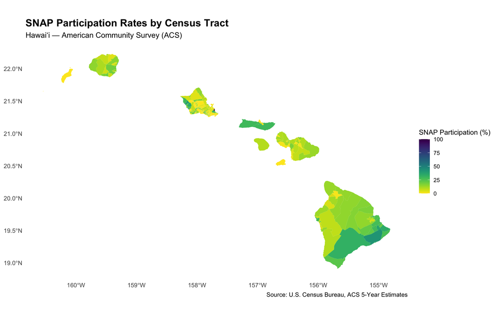

```r
# YOUR CODE HERE
# Create a ggplot map of snap_pct by census tract in Hawaii
# Remember to include title, subtitle


# Load required libraries
library(ggplot2)
library(viridis)
library(sf)
library(grid)  # for grid::margin()

ggplot(data = hi_acs) +
  geom_sf(aes(fill = snap_pct), color = NA) +
  scale_fill_viridis(
    option = "viridis",
    direction = -1,
    name = "SNAP Participation (%)"
  ) +
  labs(
    title = "SNAP Participation Rates by Census Tract",
    subtitle = "Hawaiʻi — American Community Survey (ACS)",
    caption = "Source: U.S. Census Bureau, ACS 5-Year Estimates"
  ) +
  theme_minimal(base_size = 12) +
  theme(
    panel.grid.major = element_blank(),
    panel.grid.minor = element_blank(),
    plot.title = element_text(face = "bold", size = 16),
    plot.subtitle = element_text(size = 12),
    legend.position = "right",
    legend.title = element_text(size = 11),
    legend.text = element_text(size = 9)
  )
```

**💭 Reflection on Your Map**

After creating your map, answer these questions in a comment:

1. Where are the highest concentrations of SNAP participation?

   The highest concentrations of SNAP participation are around Hilo, Molokai, and the West side of Oahu. There is also a high spot on East Side of Oahu.
2. Are there geographic patterns (islands, urban vs. rural)?

   These are all more rural locations across the Hawaiian islands.
3. What does this tell you about food security in Hawaiʻi?

   This may have something to do with the socioeconomic statuses of the people living in these rural areas, or the accessibility of resources.

## 🔍 CHALLENGE 2: Interactive Map with mapview

**Your Task**

Create an **interactive leaflet-style map** using the `mapview` package.

**Hints & Resources:** - The `mapview()` function creates interactive maps - Use `zcol = "snap_pct"` to color by SNAP participation - Set `legend = TRUE` to show a legend - Use `layer.name` to label your layer - The `at` parameter controls color breaks (try: `seq(0, max(...), by = 5)`) - Use `col.regions = viridis::viridis(10, direction = -1)` for colors

```r
# YOUR CODE HERE
# Create an interactive mapview of snap_pct

mapview(
  hi_acs,
  zcol = "snap_pct",
  legend = TRUE,
  layer.name = "SNAP Participation (%)",
  at = seq(0, max(hi_acs$snap_pct, na.rm = TRUE), by = 5),
  col.regions = viridis(10, direction = -1),
  hide = FALSE
)
```

[interactive chart not shown]

**Interactive Map Features**

With `mapview`, you can: - Zoom and pan - Click on tracts to see exact values - Toggle layers on/off - Switch between map types - Export the map

Try zooming into a specific island and exploring the variation!

## 📊 CHALLENGE 3: Histogram of SNAP Participation

**Your Task**

Create a histogram showing the distribution of `snap_pct` across all Hawaii census tracts.

**Hints & Resources:** - Use `ggplot()` with `geom_histogram()` - Consider bin width - try `bins = 20` or `binwidth = 2` - Add meaningful labels - What does the shape tell you? Is it normally distributed?

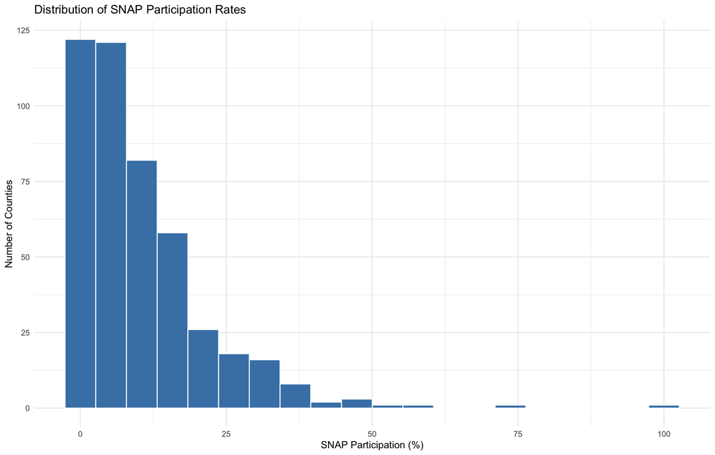

```r
# YOUR CODE HERE
# Create a histogram of snap_pct

ggplot(hi_acs, aes(x = snap_pct)) +
  geom_histogram(
    bins = 20,
    fill = "steelblue",
    color = "white"
  ) +
  labs(
    title = "Distribution of SNAP Participation Rates",
    x = "SNAP Participation (%)",
    y = "Number of Counties"
  ) +
  theme_minimal()
```

**📈 Interpretation Questions**

1. Is the distribution symmetric or skewed?

   Skewed
2. What’s the typical SNAP participation rate?

   The typical SNAP participation rate is under 25 percent. mostly under 10 percent.
3. Are there any outliers or surprising patterns?

## 🌲 Part 3: Machine Learning Setup

Now we’ll prepare for predictive modeling. First, create the ML-ready dataset:

```r
# Create ML-ready dataframe with all our features
hi_acs_data_ml <- hi_acs %>%
  st_drop_geometry() %>%                          # Remove geographic data
  select(median_income, poverty_rate_pct, uninsured_u65_pct,
         unemployment_rate_pct, broadband_pct, renter_pct, no_vehicle_pct,
         snap_pct, bachelors_or_higher_pct, commute_30plus_pct) %>%
  drop_na()                                       # Remove missing values

# Check dimensions
cat("Dataset dimensions:", dim(hi_acs_data_ml), "\n")
```

```
Dataset dimensions: 419 10
```

```r
cat("Features for modeling:", names(hi_acs_data_ml))
```

```
Features for modeling: median_income poverty_rate_pct uninsured_u65_pct unemployment_rate_pct broadband_pct renter_pct no_vehicle_pct snap_pct bachelors_or_higher_pct commute_30plus_pct
```

## 🎯 CHALLENGE 4: Build a Random Forest Model

**Your Task**

Train a Random Forest to predict SNAP participation rates using the other socioeconomic indicators.

**Your Model Should:** - Use `snap_pct` as the target variable (left side of `~`) - Use all other variables as predictors (`.` on right side) - Have `ntree = 500` for stability - Be named `rf`

**Hints & Resources:** - Use the `randomForest()` function - Formula syntax: `target ~ .` predicts target using all other columns - Structure: `randomForest(formula, data = ..., ntree = 500)` - Print the model to see performance metrics!

```r
# YOUR CODE HERE
# Build a random forest model to predict snap_pct
# Assign it to an object named 'rf'


rf = randomForest(snap_pct ~ ., data = hi_acs_data_ml, ntree = 500)
rf
```

```
Call:
 randomForest(formula = snap_pct ~ ., data = hi_acs_data_ml, ntree = 500)
               Type of random forest: regression
                     Number of trees: 500
No. of variables tried at each split: 3

          Mean of squared residuals: 46.5076
                    % Var explained: 57.98
```

**🔍 Understanding Your Model Output**

Look at the printed output and answer:

1. **Mean of squared residuals (MSR)**: How accurate are the predictions on average?

   This model captures more than half of relevant patterns, with the prediction error of 6.7% being pretty typical of social data. Since this is census data though, there is sampling/measurement noise, as well as some non-linear interactions and regional differences. The variables included in the model should also be investigated.

Remember: MSR tells you the average squared prediction error. % Var explained is like R² - higher is better!

## 🔬 Part 4: Explainable AI with SHAP

SHAP (SHapley Additive exPlanations) values explain *why* the model makes specific predictions. They break down each prediction into individual contributions from each feature.

### Understanding SHAP

Before we calculate, let’s understand what we’re doing:

1. **Unify the model**: Convert the Random Forest into a format that SHAP can work with
2. **Calculate SHAP values**: Compute explanations for a subset of observations (computing for all can be slow)
3. **Interpret**: Use the results to explain individual predictions and global patterns

## 🎯 CHALLENGE 8: Prepare SHAP Calculations

**Your Task**

Prepare the model for SHAP analysis by:

1. **Unifying** your Random Forest model using `unify()`
2. **Calculating SHAP values** for the first 200 observations using `treeshap()`

**Hints & Resources:**

- Step 1: Use `unify(your_model, your_data)` to convert the RF
  - First argument: your Random Forest object (named `rf`)
  - Second argument: your ML dataset (named `hi_acs_data_ml`)
  - Assign result to `unified`
- Step 2: Use `treeshap(unified_object, data_subset, verbose = 0)`
  - First argument: your unified model
  - Second argument: subset of data - use `hi_acs_data_ml[1:200, ]` to get first 200 rows
  - Third argument: `verbose = 0` suppresses progress messages
  - Assign result to `treeshap1`

```r
# YOUR CODE HERE
# Step 1: Unify your Random Forest model
unified <- unify(rf, hi_acs_data_ml)

# Step 2: Calculate SHAP values for first 200 observations
treeshap1 <- treeshap(unified, hi_acs_data_ml[1:200, ], verbose = 0)
```

**💭 Why Only 200 Observations?**

Computing SHAP values is computationally expensive - it can take a long time for large datasets. For this assignment, we’re calculating for a representative sample of 200 census tracts, which is enough to: - Understand which features matter globally - Examine feature dependence patterns - Look at individual case examples

In production, you might calculate for all observations or use approximation methods like TreeSHAP (which is what we’re using!).

**⚠️ Patience Required!**

The SHAP calculation might take 30 seconds to a few minutes depending on your computer. The `verbose = 0` parameter keeps it quiet while it works. You’ll know it’s done when the next code chunk starts executing!

## 📊 CHALLENGE 5: Feature Importance Plot

**Your Task**

Create a feature importance plot showing the top 5 most important variables for predicting SNAP participation.

**Hints & Resources:** - Use `plot_feature_importance(treeshap1, max_vars = 5)` - This uses the SHAP values we just calculated - The plot shows which features have the biggest impact on predictions - Longer bars = more important

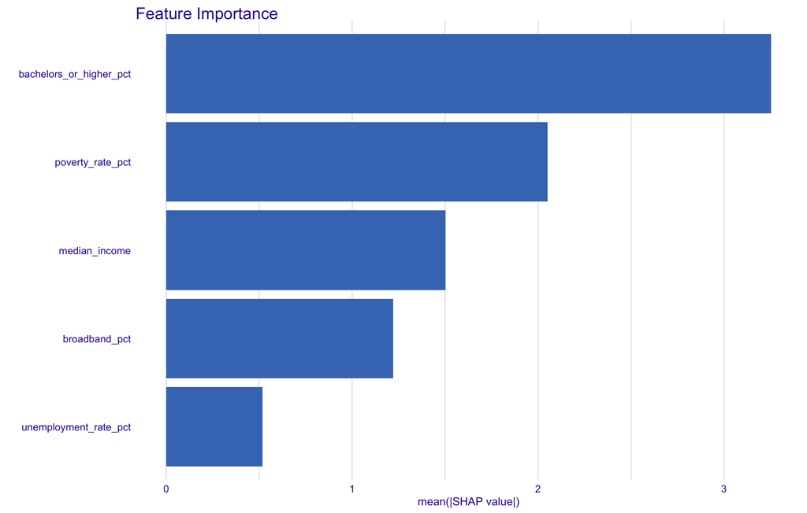

```r
# YOUR CODE HERE
# Plot feature importance (top 5 most important features)

plot_feature_importance(treeshap1, max_vars = 5)
```

**💭 Interpretation**

Based on your feature importance plot:

1. What are the TOP 2 most important predictors of SNAP participation?

   The top 2 most important predictors of SNAP participation are: bachelors_or_higher_pct and poverty_rate_pct.
2. Why do you think these variables matter?

   These variables matter since they contribute to economic status, and intuitively correlate the need for SNAP.
3. Are there any surprising results?

   The broadband_pct variable is surprising that it is in the top 5 feature importance model, but when interpreted, it makes sense that internet access is a factor of household income.
4. What does this tell you about food security in Hawaiʻi?

   This goes to show the importance of education and fighting against poverty in HI, as basic needs such as food are not met for a large group of people.

## 📈 CHALLENGE 6: Feature Dependence Plots

**Your Task**

Create feature dependence plots for the **top 5 most important features** you identified in Challenge 5.

**What to Do:** 1. Look at your feature importance plot 2. Identify the 5 most important variables 3. Create a dependence plot for each one 4. Use: `plot_feature_dependence(treeshap1, "variable_name")`

**Your Code (plot all 5):**

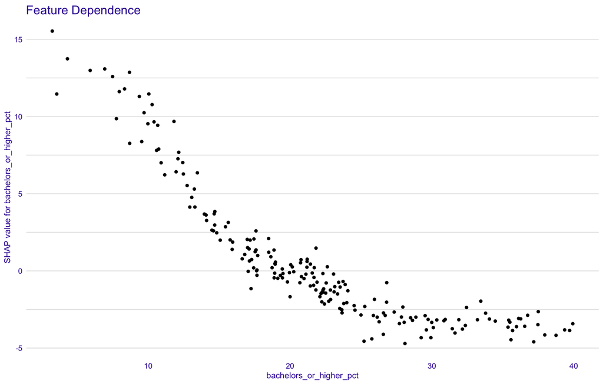

```r
# YOUR CODE HERE - Feature Dependence Plot #1
plot_feature_dependence(treeshap1, "bachelors_or_higher_pct")
```

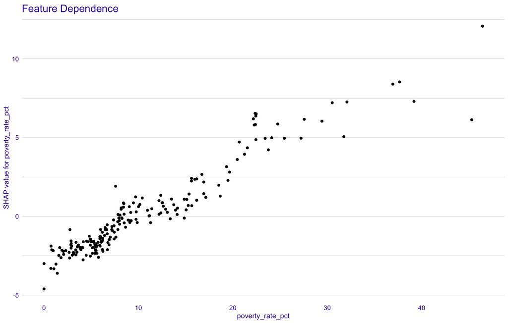

```r
# YOUR CODE HERE - Feature Dependence Plot #2
plot_feature_dependence(treeshap1, "poverty_rate_pct")
```

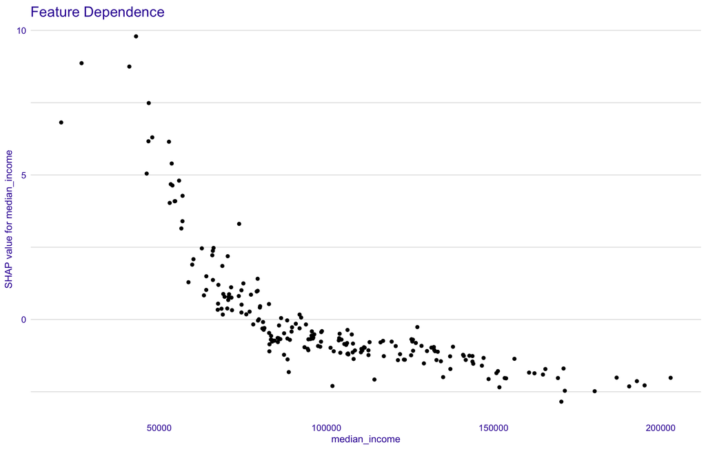

```r
# YOUR CODE HERE - Feature Dependence Plot #3
plot_feature_dependence(treeshap1, "median_income")
```

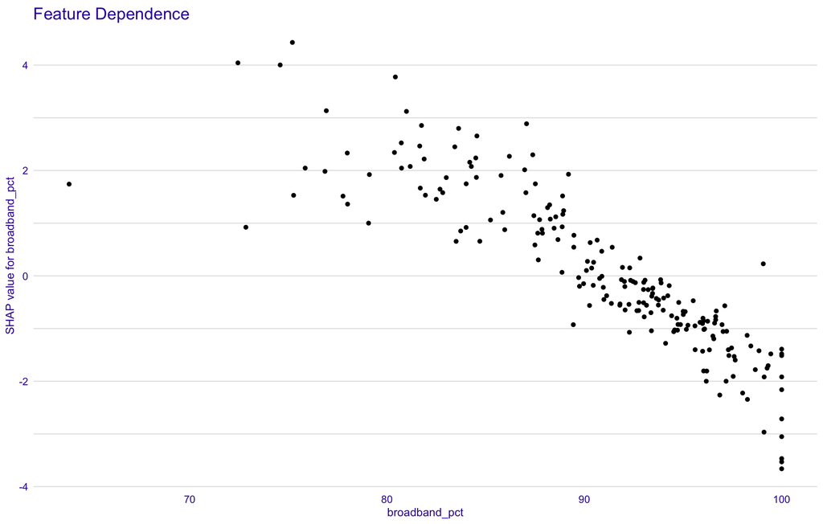

```r
# YOUR CODE HERE - Feature Dependence Plot #4
plot_feature_dependence(treeshap1, "broadband_pct")
```

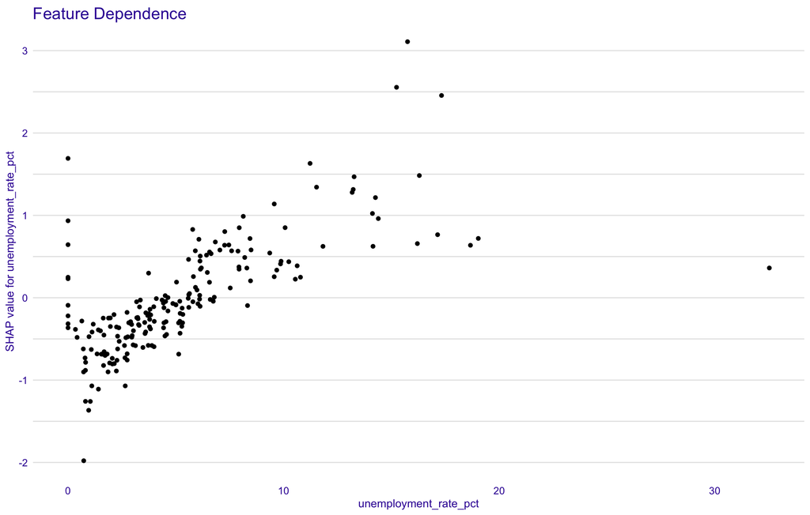

```r
# YOUR CODE HERE - Feature Dependence Plot #5
plot_feature_dependence(treeshap1, "unemployment_rate_pct")
```

**📊 Dependence Analysis Questions**

For each plot, write 1-2 sentences about:

1. **Direction**: Does higher variable value → higher or lower SNAP participation?

2. **Strength**: Is the relationship strong, moderate, or weak?

The relationship between SNAP participation and bachelors_or_higher_pct I would say is strong. The relationship between SNAP participation and poverty_rate_pct and median_income are moderately strong, and between SNAP participation and broadband_pct and unemployment_rate_pct are more weak.

3. **Pattern**: Is it linear, or are there non-linear patterns?

Between SNAP participation and bachelors_or_higher_pct, as well as SNAP participation and median_income there is an exponential (non-linear) relationship. Between SNAP participation and poverty_rate_pct, SNAP participation and broadband_pct and SNAP participation and unemployment_rate_pct, there is a linear relationship, but the strengths of each differ.

4. **Outliers**: Are there interesting outlier tracts?

Example answer: > “Poverty rate shows a strong positive relationship with SNAP participation. As poverty increases, SHAP values increase substantially, pushing predictions toward higher SNAP participation. The relationship appears roughly linear.”

An interesting outlier can be found between SNAP participation and unemployment_rate_pct. Generally, there is a moderate positive relationship between the 2 variables, but there is a case around 35% unemployment where the SNAP participation value does not follow the linear relationship, and rather, is around the median value instead of being the highest SNAP participation like the trend would expect.

## 👁️ CHALLENGE 7: Individual Tract Contribution

**Your Task**

Examine what drives predictions for **Census Tract 304.04 on Maui, Hawaiʻi**.

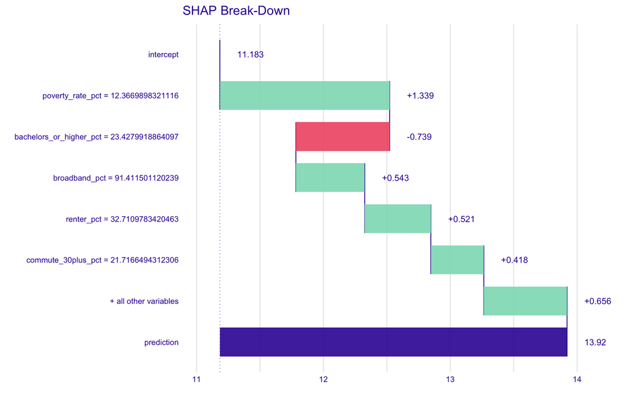

```r
# YOUR CODE HERE
# Plot contribution effects for Census Tract 304.04, Maui

plot_contribution(treeshap1, obs = 154)
```

**🔍 Case Study Analysis**

Answer these questions about Maui Census Tract 304.04:

1. **Baseline**: What’s the model’s baseline prediction?

## 🎓 Reflection & Analysis

**Final Reflection Questions**

Answer these questions in text below:

### Understanding the Analysis

1. **Model Performance**: How well does your Random Forest predict SNAP participation? What might explain the remaining unexplained variation?

     The geographic distribution of SNAP participation shows that food security disparities are not evenly spread across Hawaiʻi. Areas with the highest SNAP participation — such as Hilo, Molokaʻi, parts of Honolulu, and the west side of Oʻahu — indicate communities facing greater economic hardship and lower food security. These regions likely experience higher poverty rates, limited access to affordable groceries, and fewer employment opportunities.
   - Are certain communities more vulnerable?

     Yes, certain communities are more vulnerable. Many of these areas have historically faced economic inequities, higher costs of living, and limited access to nutritious food options. This could suggest that social and spatial inequalities — including rural isolation and urban housing costs — continue to shape food security outcomes across the islands.
4. **Limitations**:
   - What important variables might be missing from this analysis?

     Variables such as local food prices, proximity to grocery stores, social services in the area, and cultural or social attitudes toward assistance programs could be implemented into this analysis.
   - What are the limitations of predicting SNAP participation? (Remember: correlation ≠ causation)

     The model identifies statistical associations, not direct causes. Random forests can show which factors co-occur with higher or lower SNAP participation, but they cannot determine why participation differs. Also, measurement and human behavior can greatly influence a social study such as this.
5. **Policy Recommendations**:
   - Based on your findings, what 2-3 policy interventions might help address food insecurity?

     Resources should focus on communities with high SNAP participation and low food security. Increasing food pantries and grocery access, strengthening mobile and physical access to benefits, and investing in educational and workforce programs are 3 interventions that would help address food insecurity in HI.
   - Who should be targeted? Where should resources be focused?

     The communities in most need (the highest SNAP percentages) such as Hilo, Molokai, and West Oʻahu should be of priority. Focusing on these rural or low income areas would greatly increase state-wide food security.

### Technical Reflection

6. **Machine Learning Interpretation**: How did SHAP values help you understand the Random Forest model compared to just looking at variable importance?

   SHAP values provided a much deeper understanding of the Random Forest model than variable importance alone. While variable importance shows which features are influential on average, SHAP values explain how and in what direction each variable affects a specific prediction.
7. **Next Steps**: If you were to continue this analysis, what would you do next?

   If I were to continue this analysis, I would incorporate additional variables such as food costs, distance to grocery stores, or local policy factors. I would also like to look at trends over time, as well as testing other models/variable combinations.

## ⭐ BONUS: Extension Challenges

**For Extra Credit**

Try one or more of these extensions:

Did not have time to attempt.

### Extension 1: Regional Analysis

- Split Hawaiʻi by island (using `GEOID` or geographic location)
- Build separate Random Forest models for each island
- Compare which factors matter most on each island

### Extension 2: Relationship Exploration

- Create scatter plots showing relationships between top predictors and SNAP%
- Calculate correlation coefficients
- Which relationships are strongest?

### Extension 3: Model Comparison

- Build a **second** Random Forest with different parameters (e.g., `mtry`, `nodesize`)
- Compare performance to your original model
- Which performs better?

### Extension 4: Prediction Intervals

- For a new hypothetical census tract, use your model to predict SNAP participation
- What would be needed to create prediction intervals?
- How confident would you be in that prediction?

### Extension 5: Data Visualization

- Create a multi-panel visualization combining:
  - The map of SNAP participation
  - Distribution histogram
  - Top feature importance plot
  - Tell a complete visual story

## 📝 Submission Checklist

- All 8 challenges completed with code
- Written explanations for each challenge
- Reflection questions answered thoroughly
- Code is commented and readable
- Plots are properly labeled with titles/legends
- At least one bonus challenge attempted (optional)
- **Rendered to PDF and submitted to Canvas**

## 📤 How to Render & Submit

### Step 1: Render to HTML

In RStudio, click the blue **“Render”** button at the top of the editor pane.

Wait for the rendering to complete - you’ll see the document appear in the **Viewer pane** (bottom right).

**Tip**

**Rendering typically takes 2-5 minutes depending on how fast your computer is. Be patient!**

### Step 2: Open in New Window

In the **Viewer pane**, click the **“Show in new window”** icon (it looks like an arrow pointing to a box, usually in the top-right corner of the viewer).

Your rendered HTML document will open in your default web browser.

### Step 3: Print to PDF

1. In your browser, press **`Ctrl + P`** (Windows) or **`Cmd + P`** (Mac)
2. A print dialog will appear
3. Change the destination to **“Save as PDF”**
4. Give it a clear name: `LastName_FirstName_ml_assignment.pdf`
5. Click **“Save”**

Your PDF will download to your Downloads folder (or wherever your browser saves files).

### Step 4: Upload to Canvas

1. Go to your Canvas course page
2. Find the assignment: “Hawaii SNAP Analysis Homework”
3. Click **“Submit Assignment”**
4. Click **“Choose File”** and select your PDF
5. Click **“Submit”**

**Important Reminders**

- ✅ Make sure your `.qmd` file renders **without errors** before saving as PDF
- ✅ Double-check that all your challenge code is visible in the HTML output
- ✅ Your PDF should include both your code AND the results/plots
- ✅ Save the PDF file somewhere you can find it (Desktop or a course folder)
- ⏱️ Allow 5-10 minutes total for rendering and saving

### Troubleshooting

**“Render button is grayed out?”** - Make sure you have the `.qmd` file open in the editor (not just viewed)

**“I don’t see a Viewer pane?”** - Go to `View` → `Panes` → `Show Viewer Pane`

**“Nothing appears after clicking Render?”** - Check the R console for error messages - Make sure all your code runs without errors first - Try re-rendering after fixing any issues

## 📚 Resources & References

- [tidycensus Documentation](https://walker-data.com/tidycensus/)
- [Census Bureau Data Catalog](https://data.census.gov/)
- [SHAP Documentation](https://shap.readthedocs.io/)
- [Random Forests in R](https://cran.r-project.org/web/packages/randomForest/randomForest.pdf)
- [mapview Package](https://r-spatial.github.io/mapview/)

*Good luck! Remember: focus on understanding WHAT you’re doing and WHY, not just running code. Ask questions, explore the data, and enjoy the detective work of data science! 🔍📊*